# R Assignment

Tuqa Ibrahim

2026-03-15

# Introduction

In this report, we analyze two input files:

- `fang_et_al_genotypes.txt`: contains SNP genotype data from maize, teosinte, and Tripsacum samples.
- `snp_position.txt`: contains information about the SNPs in `fang_et_al_genotypes.txt`, including SNP ID, chromosome location, nucleotide position, and other related information.

This report has three main parts: data inspection, data processing, and data visualization.

## Data Inspection

In this part, we examine the input data files to understand their structure, dimensions, data types, and general organization.

We begin by loading the two input files: the genotype dataset and the SNP position dataset into R using ‘read_tsv()’.

```r
#Read the files
genotypes <- read_tsv("data/fang_et_al_genotypes.txt", show_col_types = FALSE)
snp_positions <- read_tsv("data/snp_position.txt", show_col_types = FALSE)
```

By inspecting the two files, we learn their dimensions, column names, data types, and examine a preview of the first rows.

```r
#Inspect the data
dim(genotypes)
```

```
## [1] 2782  986
```

```r
dim(snp_positions)
```

```
## [1] 983  15
```

```r
names(genotypes)[1:15]
```

```
##  [1] "Sample_ID" "JG_OTU"    "Group"     "abph1.20"  "abph1.22"  "ae1.3"
##  [7] "ae1.4"     "ae1.5"     "an1.4"     "ba1.6"     "ba1.9"     "bt2.5"
## [13] "bt2.7"     "bt2.8"     "Fea2.1"
```

```r
names(snp_positions)
```

```
##  [1] "SNP_ID"               "cdv_marker_id"        "Chromosome"
##  [4] "Position"             "alt_pos"              "mult_positions"
##  [7] "amplicon"             "cdv_map_feature.name" "gene"
## [10] "candidate/random"     "Genaissance_daa_id"   "Sequenom_daa_id"
## [13] "count_amplicons"      "count_cmf"            "count_gene"
```

```r
head(genotypes)
```

```
## # A tibble: 6 × 986
##   Sample_ID JG_OTU   Group abph1.20 abph1.22 ae1.3 ae1.4 ae1.5 an1.4 ba1.6 ba1.9
##   <chr>     <chr>    <chr> <chr>    <chr>    <chr> <chr> <chr> <chr> <chr> <chr>
## 1 SL-15     T-aust-1 TRIPS ?/?      ?/?      T/T   G/G   T/T   C/C   ?/?   G/G
## 2 SL-16     T-aust-2 TRIPS ?/?      ?/?      T/T   ?/?   T/T   C/C   A/G   G/G
## 3 SL-11     T-brav-1 TRIPS ?/?      ?/?      T/T   G/G   T/T   ?/?   G/G   G/G
## 4 SL-12     T-brav-2 TRIPS ?/?      ?/?      T/T   G/G   T/T   C/C   G/G   G/G
## 5 SL-18     T-cund   TRIPS ?/?      ?/?      T/T   G/G   T/T   C/C   ?/?   G/G
## 6 SL-2      T-dact-1 TRIPS ?/?      ?/?      T/T   G/G   T/T   C/C   A/G   G/G
## # ℹ 975 more variables: bt2.5 <chr>, bt2.7 <chr>, bt2.8 <chr>, Fea2.1 <chr>,
## #   Fea2.5 <chr>, id1.3 <chr>, lg2.11 <chr>, lg2.2 <chr>, pbf1.1 <chr>,
## #   pbf1.2 <chr>, pbf1.3 <chr>, pbf1.5 <chr>, pbf1.6 <chr>, pbf1.7 <chr>,
## #   pbf1.8 <chr>, PZA00003.11 <chr>, PZA00004.2 <chr>, PZA00005.8 <chr>,
## #   PZA00005.9 <chr>, PZA00006.13 <chr>, PZA00006.14 <chr>, PZA00008.1 <chr>,
## #   PZA00010.5 <chr>, PZA00013.10 <chr>, PZA00013.11 <chr>, PZA00013.9 <chr>,
## #   PZA00015.4 <chr>, PZA00017.1 <chr>, PZA00018.5 <chr>, PZA00029.11 <chr>, …
```

```r
head(snp_positions)
```

```
## # A tibble: 6 × 15
##   SNP_ID   cdv_marker_id Chromosome Position  alt_pos mult_positions amplicon
##   <chr>            <dbl> <chr>      <chr>     <chr>   <chr>          <chr>
## 1 abph1.20          5976 2          27403404  <NA>    <NA>           abph1
## 2 abph1.22          5978 2          27403892  <NA>    <NA>           abph1
## 3 ae1.3             6605 5          167889790 <NA>    <NA>           ae1
## 4 ae1.4             6606 5          167889682 <NA>    <NA>           ae1
## 5 ae1.5             6607 5          167889821 <NA>    <NA>           ae1
## 6 an1.4             5982 1          240498509 <NA>    <NA>           an1
## # ℹ 8 more variables: cdv_map_feature.name <chr>, gene <chr>,
## #   `candidate/random` <chr>, Genaissance_daa_id <dbl>, Sequenom_daa_id <dbl>,
## #   count_amplicons <dbl>, count_cmf <dbl>, count_gene <dbl>
```

```r
sapply(genotypes [1:15], class)
```

```
##   Sample_ID      JG_OTU       Group    abph1.20    abph1.22       ae1.3
## "character" "character" "character" "character" "character" "character"
##       ae1.4       ae1.5       an1.4       ba1.6       ba1.9       bt2.5
## "character" "character" "character" "character" "character" "character"
##       bt2.7       bt2.8      Fea2.1
## "character" "character" "character"
```

```r
sapply(snp_positions, class)
```

```
##               SNP_ID        cdv_marker_id           Chromosome
##          "character"            "numeric"          "character"
##             Position              alt_pos       mult_positions
##          "character"          "character"          "character"
##             amplicon cdv_map_feature.name                 gene
##          "character"          "character"          "character"
##     candidate/random   Genaissance_daa_id      Sequenom_daa_id
##          "character"            "numeric"            "numeric"
##      count_amplicons            count_cmf           count_gene
##            "numeric"            "numeric"            "numeric"
```

```r
unique(genotypes[[3]])
```

```
##  [1] "TRIPS" "ZDIPL" "ZPERR" "ZLUXR" "ZMHUE" "ZMPBA" "ZMPJA" "ZMXCH" "ZMXCP"
## [10] "ZMXNO" "ZMXNT" "ZMPIL" "ZMXIL" "ZMMLR" "ZMMMR" "ZMMIL"
```

## Data Processing

The genotype data is filtered to keep only maize and teosinte samples. We exclude Tripsacum because the assignment focuses only on maize and teosinte. The genotype data is split into maize (Group = ZMMIL, ZMMLR, and ZMMMR) and teosinte (Group = ZMPBA, ZMPIL, and ZMPJA) genotype files.

```r
#Filter maize and teosinte groups
maize <- filter(genotypes, Group %in% c("ZMMIL", "ZMMLR", "ZMMMR"))
teosinte <- filter(genotypes, Group %in% c("ZMPBA", "ZMPIL", "ZMPJA"))
```

After filtering, we separate the metadata columns from the SNP genotype columns so that only the genotype data are used for downstream SNP processing.

```r
#Remove metadata and create new genotype files for maize and teosinte keeping only the SNPs genotypes columns
genotype_columns <- 4:ncol(genotypes)
maize_genotypes <- maize[, genotype_columns]
teosinte_genotypes <- teosinte[, genotype_columns]
```

Now we transpose these files so that each row represents a SNP ID rather than a sample ID. For the transposed dataframe, we need a proper SNP_ID column, so we convert the SNP identifiers from row names into a proper SNP_ID column, and the sample IDs are assigned as column names. After reordering columns so SNP_ID comes first, the gynotype files is ready a for merging with the SNP position information.

```r
#Transpose the genotype files
maize_transpose <- as.data.frame(t(maize_genotypes))
teosinte_transpose <- as.data.frame(t(teosinte_genotypes))

#Take the sample names from original files and use it as column names for the transposed files
colnames(maize_transpose) <- maize[[1]]
colnames(teosinte_transpose) <- teosinte[[1]]

#Make the row names in the transposed files a real column called SNP_ID
maize_transpose$SNP_ID <- rownames(maize_transpose)
teosinte_transpose$SNP_ID <- rownames(teosinte_transpose)

#Reorder columns so SNP_ID comes first
maize_transpose <- select(maize_transpose, SNP_ID, everything())
teosinte_transpose <- select(teosinte_transpose, SNP_ID, everything())

#Remove row names
rownames(maize_transpose) <- NULL
rownames(teosinte_transpose) <- NULL
```

We need only specific columns from the SNP position dataset, so we reduce it to the three relevant columns: SNP_ID, Chromosome, and Position.

```r
#Keep only the three requested columns in the SNP position file
snp_important_info <- select(snp_positions, 1, 3, 4)
```

These columns are joined with the transposed maize and teosinte genotype datasets using ‘inner_join()’ to keep only the matched rows in the two files.

```r
#Joining SNP position info to the transposed genotype data
maize_all_joined <- inner_join(snp_important_info, maize_transpose, by = "SNP_ID")
teosinte_all_joined <- inner_join(snp_important_info, teosinte_transpose, by = "SNP_ID")
```

```r
#Check the class of Chromosome and Position columns
class(maize_all_joined$Chromosome)
```

```
## [1] "character"
```

```r
class(maize_all_joined$Position)
```

```
## [1] "character"
```

```r
#Converting Chromosome and Position columns into numeric so they can be sorted
maize_all_joined <- mutate(maize_all_joined, Chromosome = as.numeric(Chromosome), Position = as.numeric(Position))
teosinte_all_joined <- mutate(teosinte_all_joined, Chromosome = as.numeric(Chromosome), Position = as.numeric(Position))

#Check the new class of Chromosome and Position columns
class(maize_all_joined$Chromosome)
```

```
## [1] "numeric"
```

```r
class(maize_all_joined$Position)
```

```
## [1] "numeric"
```

```r
#remove rows with missing chromosome or position
maize_all_joined <- filter(maize_all_joined, !is.na(Chromosome), !is.na(Position))
teosinte_all_joined <- filter(teosinte_all_joined, !is.na(Chromosome), !is.na(Position))
```

A special function is then created to generate chromosome-specific output files for both maize and teosinte. It generates two files for each chromosome from 1 to 10: one sorted in increasing genomic position and one sorted in decreasing genomic position. In addition, missing genotype data (?/?) are encoded by this symbol: “?” and this symbol: “-” as required by the assignment.

```r
#Define a function to generate chromosome files
create_chromosome_files <- function(df, group) {
  lapply(1:10, function(chromosome_number) {

    chromosome_df <- filter(df, Chromosome == chromosome_number)

    chromosome_increasing_order <- chromosome_df %>%
      arrange(Position) %>%
      mutate(across(4:ncol(.), ~replace(., . == "?/?", "?")))

    chromosome_decreasing_order <- chromosome_df %>%
      arrange(desc(Position)) %>%
      mutate(across(4:ncol(.), ~replace(., . == "?/?", "-")))

    write_tsv(
      chromosome_increasing_order,
      paste0("output/processed_files/", group, "_chromosome", chromosome_number, "_increasing_order.txt")
    )

    write_tsv(
      chromosome_decreasing_order,
      paste0("output/processed_files/", group, "_chromosome", chromosome_number, "_decreasing_order.txt")
    )
  })
}
```

```r
# Create the chromosome files
create_chromosome_files(maize_all_joined, "maize")
create_chromosome_files(teosinte_all_joined, "teosinte")
```

## Data Visualization

For the first visualization, we generate a bar plot showing the total number of SNP positions per chromosome for maize and teosinte.

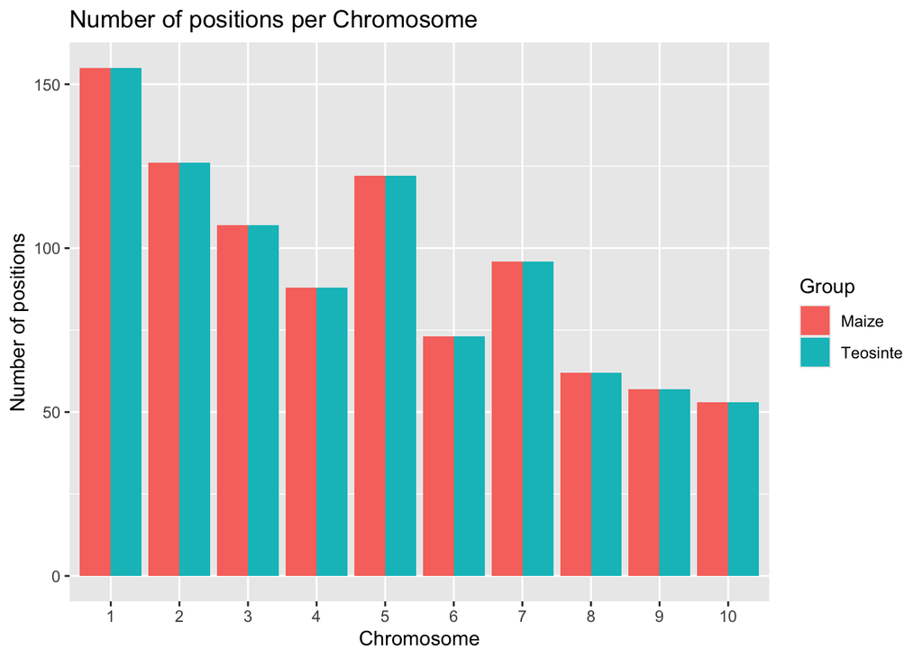

```r
#Generate the first plot (Positions per chromosome)
maize_modified_for_plot <- maize_all_joined %>%
  select(SNP_ID, Chromosome, Position) %>%
  mutate(Group = "Maize")

teosinte_modified_for_plot <- teosinte_all_joined %>%
  select(SNP_ID, Chromosome, Position) %>%
  mutate(Group = "Teosinte")

total_snp_modified_for_plot <- bind_rows(maize_modified_for_plot, teosinte_modified_for_plot)

p1 <- ggplot(total_snp_modified_for_plot, aes(x = factor(Chromosome), fill = Group)) +
  geom_bar(position = "dodge") +
  labs(
    title = "Number of positions per Chromosome",
    x = "Chromosome",
    y = "Number of positions"
  )
p1
```

```r
#Save plot
ggsave("output/visuals/positions_per_chromosome.png", plot = p1, width = 8, height = 5)
```

This plot shows that both maize and teosinte have the same total number of positions, which is expected because both groups are joined to the same SNP position file. However, not every position represents a truly polymorphic SNP. To address this, we identify the SNP positions that show variation in genotype across individuals.

To check for polymorphic SNPs, each SNP row is tested for variation across individuals within the maize group and within the teosinte group. We exclude missing genotype data from this check. A SNP is classified as a polymorphic SNP if more than one unique genotype (non-missing) is present among individuals. Then, we count the polymorphic SNPs per chromosome and visualize them in the second bar plot.

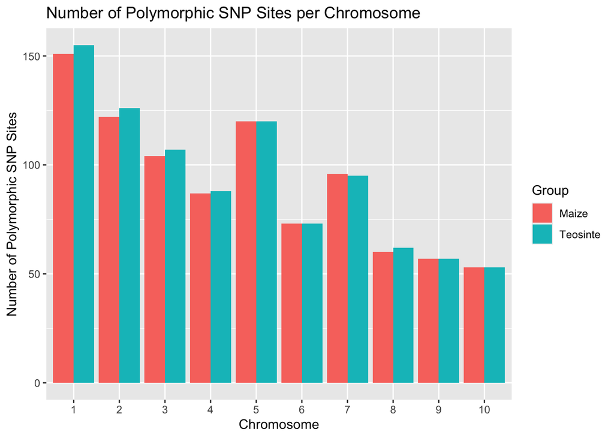

```r
#Generate the second plot (SNPs per chromosome)
polymolrphic_SNPs_in_maize <- maize_all_joined %>%
  mutate(
    Polymorphic = apply(select(., 4:ncol(.)), 1, function(x) {
      x <- x[!x %in% c("?/?")]
      length(unique(x)) > 1
    })
  )

polymorphic_SNPs_in_teosinte <- teosinte_all_joined %>%
  mutate(
    Polymorphic = apply(select(., 4:ncol(.)), 1, function(x) {
      x <- x[!x %in% c("?/?")]
      length(unique(x)) > 1
    })
  )

snps_in_Maize_final <- polymolrphic_SNPs_in_maize %>%
  filter(Polymorphic) %>%
  mutate(Group = "Maize")

snps_in_Teosinte_final <- polymorphic_SNPs_in_teosinte %>%
  filter(Polymorphic) %>%
  mutate(Group = "Teosinte")

final_poly_snp <- bind_rows(snps_in_Maize_final, snps_in_Teosinte_final)

p2 <- ggplot(final_poly_snp, aes(x = factor(Chromosome), fill = Group)) +
  geom_bar(position = "dodge") +
  labs(
    title = "Number of Polymorphic SNP Sites per Chromosome",
    x = "Chromosome",
    y = "Number of Polymorphic SNP Sites"
  )
p2
```

```r
#Save plot
ggsave("output/visuals/polymorphic_SNPs_per_chromosome.png", plot = p2, width = 8, height = 5)
```

Now we can see a difference. Teosinte has either the same number or more polymorphic SNPs per chromosome than maize, except for chromosome 7, where maize has more polymorphic SNPs.

For the next four plots, we examine genotype composition in more detail. In order to do that, we reshape the maize and teosinte datasets from wide format to long format using ‘pivot_longer()’. This creates a structure where each row corresponds to one SNP call for one sample. We then classify each genotype as missing, homozygous, or heterozygous.

Using this long-format dataset, we produce the following plots: the proportion of genotype classes for each sample, the proportion of genotype classes for each group, the proportion of missing data by chromosome and group, and the proportion of genotype classes across chromosomes.

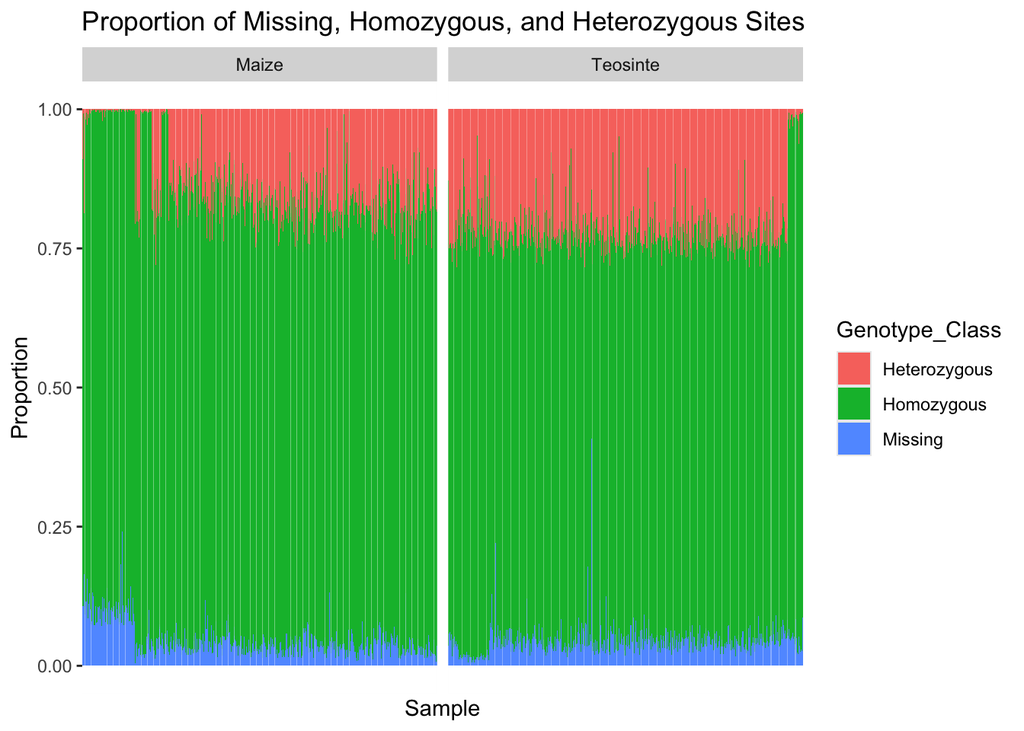

```r
##Generate the third plot (proportion of homozygous, heterozygous, and missing data in each sample)

#Reshape genotype data into long format for plotting
Maize_Long <- maize_all_joined %>%
  pivot_longer(
    cols = 4:ncol(.),
    names_to = "Sample",
    values_to = "Genotype"
  ) %>%
  mutate(Group = "Maize")

Teosinte_Long <- teosinte_all_joined %>%
  pivot_longer(
    cols = 4:ncol(.),
    names_to = "Sample",
    values_to = "Genotype"
  ) %>%
  mutate(Group = "Teosinte")

Teosinte_and_Maize_Long <- bind_rows(Maize_Long, Teosinte_Long)

Teosinte_and_Maize_Long <- Teosinte_and_Maize_Long %>%
  mutate(
    Genotype_Class = case_when(
      Genotype %in% c("?/?") ~ "Missing",
      Genotype %in% c("A/A", "C/C", "G/G", "T/T") ~ "Homozygous",
      TRUE ~ "Heterozygous"
    )
  )

p3 <- ggplot(Teosinte_and_Maize_Long, aes(x = Sample, fill = Genotype_Class)) +
  geom_bar(position = "fill") +
  facet_wrap(~ Group, scales = "free_x") +
  labs(
    title = "Proportion of Missing, Homozygous, and Heterozygous Sites",
    x = "Sample",
    y = "Proportion"
  ) +
  theme(axis.text.x = element_blank(),
        axis.ticks.x = element_blank())
p3
```

```r
#Save plot
ggsave("output/visuals/genotype_class_by_sample.png", plot = p3, width = 8, height = 5)
```

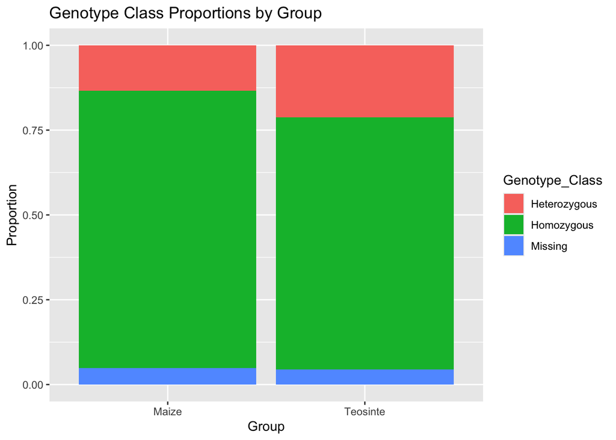

```r
##Generate the fourth plot (proportion of homozygous, heterozygous, and missing data in each group)
proportions_per_group_summary <- Teosinte_and_Maize_Long %>%
  count(Group, Genotype_Class) %>%
  group_by(Group) %>%
  mutate(Proportion = n / sum(n))

p4 <- ggplot (proportions_per_group_summary, aes(x = Group, y = Proportion, fill = Genotype_Class)) +
  geom_col(position = "fill") +
  labs(
    title = "Genotype Class Proportions by Group",
    x = "Group",
    y = "Proportion"
  )
p4
```

```r
#Save plot
ggsave("output/visuals/proportions_per_group.png", plot = p4, width = 8, height = 5)
```

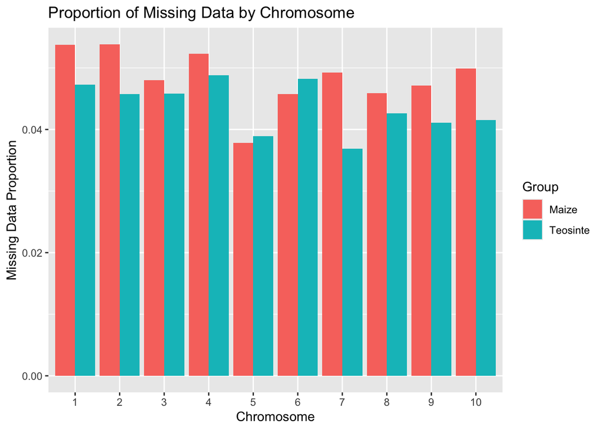

```r
# Generate the fifth plot (Missing data by chromosome and group)
missing_by_chromosome <- Teosinte_and_Maize_Long %>%
  mutate(Is_Missing = Genotype_Class == "Missing") %>%
  group_by(Group, Chromosome) %>%
  summarise(
    Missing_Proportion = mean(Is_Missing),
    .groups = "drop"
  )

p5 <- ggplot(missing_by_chromosome, aes(x = factor(Chromosome), y = Missing_Proportion, fill = Group)) +
  geom_col(position = "dodge") +
  labs(
    title = "Proportion of Missing Data by Chromosome",
    x = "Chromosome",
    y = "Missing Data Proportion"
  )
p5
```

```r
#Save plot
ggsave("output/visuals/missing_data_per_chromosome_and_group.png", plot = p5, width = 8, height = 5)
```

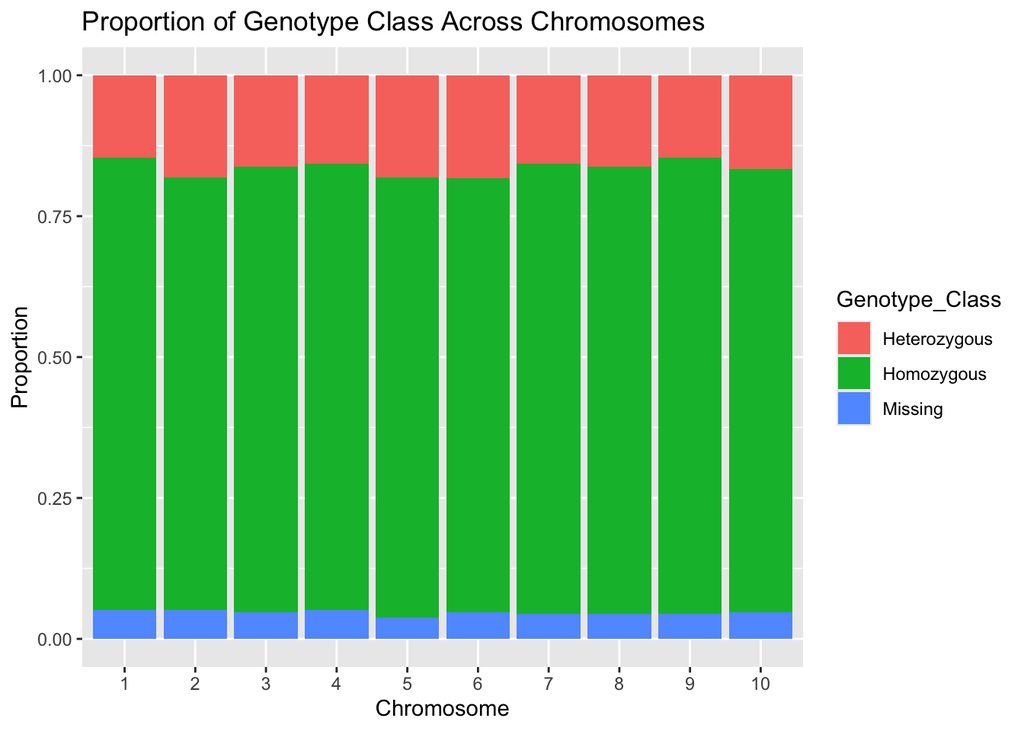

```r
 # Generate the sixth plot (proportion of homozygous, heterozygous, and missing data in each chromosome)
p6 <- ggplot(Teosinte_and_Maize_Long, aes(x = as.factor(Chromosome), fill = Genotype_Class)) +
  geom_bar(position = "fill") +
  labs(title = "Proportion of Genotype Class Across Chromosomes", x = "Chromosome", y = "Proportion")
p6
```

```r
#Save plot
ggsave("output/visuals/proportion_of_genotype_class_per_chromosome.png", plot = p6, width = 8, height = 5)
```

All plots are saved to the ‘output/visuals’ folder after viewing, and the chromosome-specific processed files are written to the ‘output/processed_files’ folder.